# Estimating the current size of the 2026 DRC Bundibugyo virus outbreak: a joint Bayesian re-analysis of the McCabe et al. report

### Delay sensitivity

Refit under the community-only onset-to-death delay: the baseline and refitted posteriors side by side.

**Refit the joint model with the community-only delay**

julia

```julia
community_delay = delay_model(;
    alpha_prior = truncated(Normal(5.6, (25.9 - 1.0) / 3.92); lower = 0),
    theta_prior = truncated(Normal(1.4, (9.5 - 0.3) / 3.92); lower = 0))

chn_joint_community = nuts_sample(
    bvd_joint(obs.exported_cases, fit_args.deaths, fit_args.reported,
    fit_args.export_deaths; fit_args.kw...,
    growth = growth_now,
    first_export_detection_delta = obs.first_export_detection_delta,
    genetic = genetic_seeding,
    deaths = (total_deaths,
        growth_state,
        k,
        t_edges;
        kwargs...) -> deaths_model(total_deaths, growth_state, k, t_edges;
        delay = community_delay, kwargs...)));

posterior_C_community = vec(Array(chn_joint_community[:cumulative_cases]));
```

[output not shown]

Fit diagnostics for the community-only delay refit.

**Fit diagnostics**

1×4 DataFrame

| Row | fit String | max_rhat Float64 | min_ess_bulk Float64 | divergences Int64 |
| --- | --- | --- | --- | --- |
| 1 | joint (community-only delay) | 1.008 | 261.0 | 57 |

Baseline versus community-only delay, side by side:

**Delay-sensitivity C_T table**

julia

```julia
delay_sensitivity_table = streams_table(
    "joint (baseline delay)" => posterior_C_joint,
    "joint (community-only delay)" => posterior_C_community);
```

2×7 DataFrame

| Row | Stream String | Lower 90% Float64 | Lower 60% Float64 | Lower 30% Float64 | Upper 30% Float64 | Upper 60% Float64 | Upper 90% Float64 |
| --- | --- | --- | --- | --- | --- | --- | --- |
| 1 | joint (baseline delay) | 3213.0 | 3845.0 | 4250.0 | 5176.0 | 5931.0 | 7665.0 |
| 2 | joint (community-only delay) | 3163.0 | 3724.0 | 4138.0 | 5034.0 | 5767.0 | 7696.0 |

Overlaid posterior densities of under the two delay assumptions:

**Delay-sensitivity C_T density plot**

julia

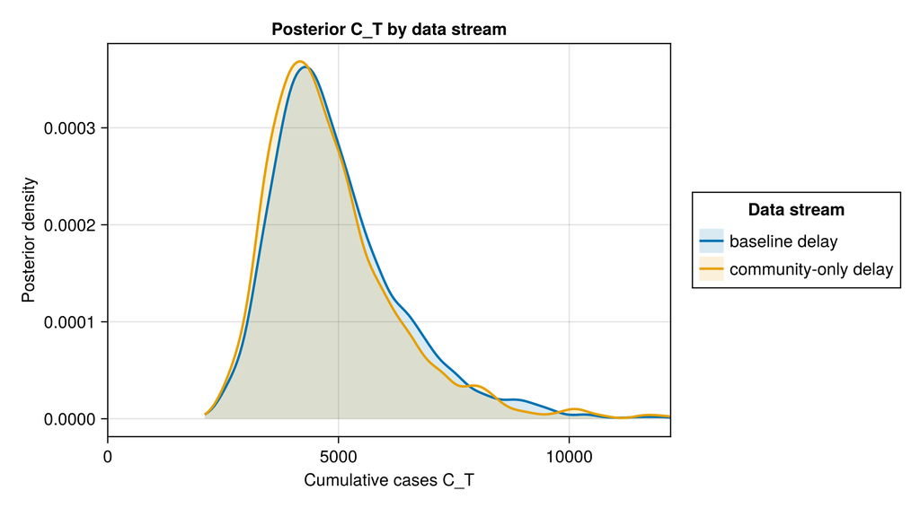

```julia
delay_sensitivity_fig = plot_cumulative_cases(
    "baseline delay" => posterior_C_joint,
    "community-only delay" => posterior_C_community;
    scenarios = []);
```

### Clock-rate sensitivity

**Refit the joint model under the 1.9e-3 clock**

julia

```julia
genetic_seeding_clock19 = T -> genetic_seeding_model(T,
    obs.genetic_tmrca_alt_days;
    tmrca_days_sd = obs.genetic_tmrca_alt_days_sd)

chn_joint_clock19 = nuts_sample(
    bvd_joint(obs.exported_cases, fit_args.deaths, fit_args.reported,
    fit_args.export_deaths; fit_args.kw...,
    growth = growth_now,
    first_export_detection_delta = obs.first_export_detection_delta,
    genetic = genetic_seeding_clock19));

posterior_C_clock19 = vec(Array(chn_joint_clock19[:cumulative_cases]));
```

[output not shown]

Fit diagnostics for the 1.9e-3 clock-rate refit.

**Fit diagnostics**

1×4 DataFrame

| Row | fit String | max_rhat Float64 | min_ess_bulk Float64 | divergences Int64 |
| --- | --- | --- | --- | --- |
| 1 | joint (1.9e-3 clock) | 1.009 | 295.0 | 35 |

Each quantity is shown as a side-by-side table followed by overlaid posterior densities under the two clock rates.

Outbreak size :

**Clock-rate C_T table**

julia

```julia
clock_sensitivity_C_table = streams_table(
    "joint (1.2e-3 clock)" => posterior_C_joint,
    "joint (1.9e-3 clock)" => posterior_C_clock19);
```

2×7 DataFrame

| Row | Stream String | Lower 90% Float64 | Lower 60% Float64 | Lower 30% Float64 | Upper 30% Float64 | Upper 60% Float64 | Upper 90% Float64 |
| --- | --- | --- | --- | --- | --- | --- | --- |
| 1 | joint (1.2e-3 clock) | 3213.0 | 3845.0 | 4250.0 | 5176.0 | 5931.0 | 7665.0 |
| 2 | joint (1.9e-3 clock) | 3205.0 | 3849.0 | 4251.0 | 5156.0 | 5826.0 | 7338.0 |

**Clock-rate C_T density plot**

julia

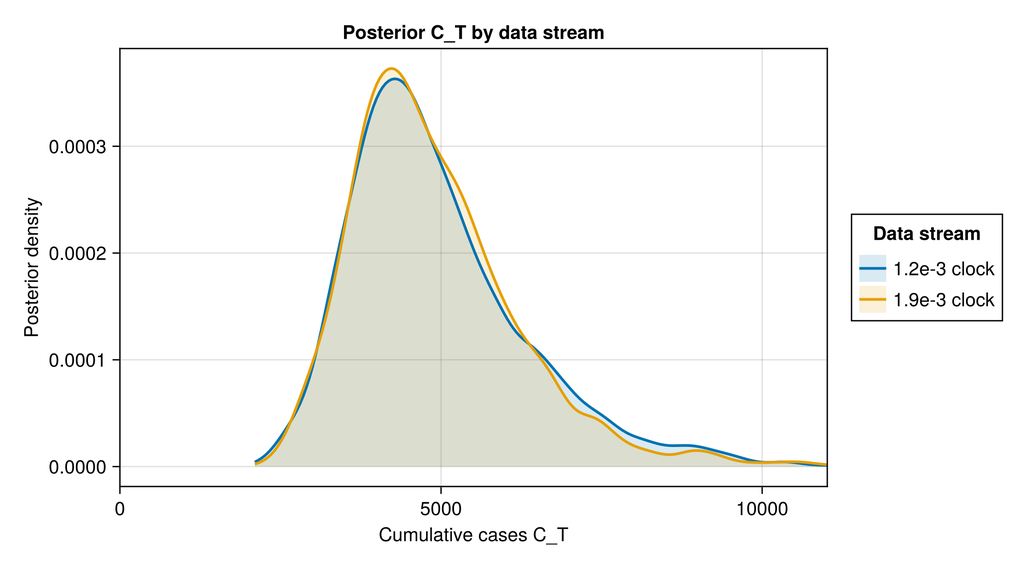

```julia
clock_sensitivity_C_fig = plot_cumulative_cases(
    "1.2e-3 clock" => posterior_C_joint,
    "1.9e-3 clock" => posterior_C_clock19;
    scenarios = []);
```

Seeding time (days before the cut-off); a more recent TMRCA permits later seeding:

**Clock-rate seeding-time table**

julia

```julia
T_clock12 = vec(Array(chn_joint[:T]));
T_clock19 = vec(Array(chn_joint_clock19[:T]));

clock_sensitivity_T_table = streams_table(
    "joint (1.2e-3 clock)" => T_clock12,
    "joint (1.9e-3 clock)" => T_clock19;
    digits = 0);
```

2×7 DataFrame

| Row | Stream String | Lower 90% Float64 | Lower 60% Float64 | Lower 30% Float64 | Upper 30% Float64 | Upper 60% Float64 | Upper 90% Float64 |
| --- | --- | --- | --- | --- | --- | --- | --- |
| 1 | joint (1.2e-3 clock) | 167.0 | 184.0 | 196.0 | 219.0 | 234.0 | 264.0 |
| 2 | joint (1.9e-3 clock) | 165.0 | 185.0 | 197.0 | 221.0 | 237.0 | 263.0 |

**Clock-rate seeding-time density plot**

julia

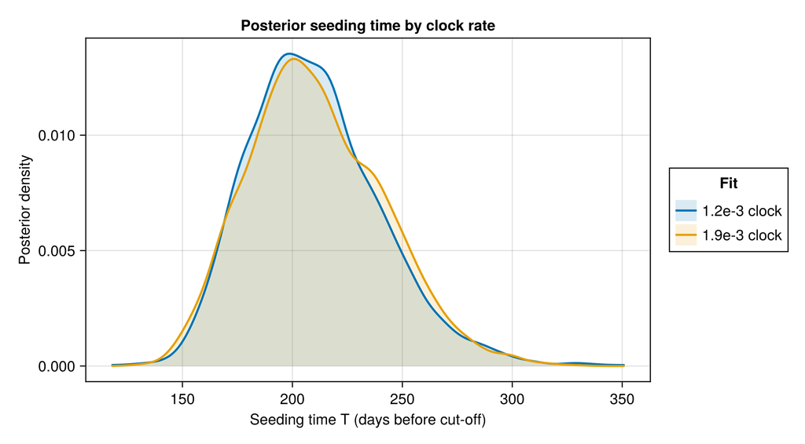

```julia
clock_sensitivity_T_fig = plot_density_overlay(
    "1.2e-3 clock" => T_clock12,
    "1.9e-3 clock" => T_clock19;
    xlabel = "Seeding time T (days before cut-off)",
    title = "Posterior seeding time by clock rate");
```

Growth rate (per day); later seeding implies faster growth to reach the same observed counts:

**Clock-rate growth-rate table**

julia

```julia
r_clock12 = vec(Array(chn_joint[:r]));
r_clock19 = vec(Array(chn_joint_clock19[:r]));

clock_sensitivity_r_table = streams_table(
    "joint (1.2e-3 clock)" => r_clock12,
    "joint (1.9e-3 clock)" => r_clock19;
    digits = 3);
```

2×7 DataFrame

| Row | Stream String | Lower 90% Float64 | Lower 60% Float64 | Lower 30% Float64 | Upper 30% Float64 | Upper 60% Float64 | Upper 90% Float64 |
| --- | --- | --- | --- | --- | --- | --- | --- |
| 1 | joint (1.2e-3 clock) | 0.033 | 0.037 | 0.04 | 0.044 | 0.047 | 0.053 |
| 2 | joint (1.9e-3 clock) | 0.033 | 0.037 | 0.039 | 0.044 | 0.047 | 0.053 |

**Clock-rate growth-rate density plot**

julia

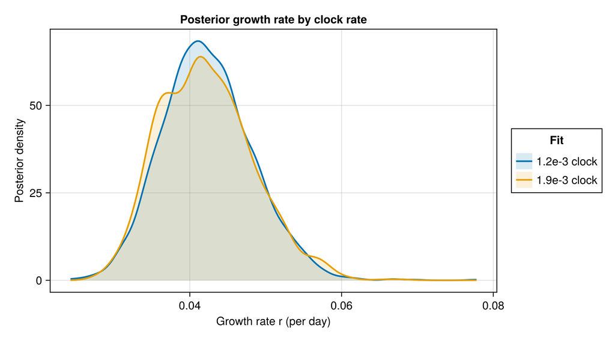

```julia
clock_sensitivity_r_fig = plot_density_overlay(
    "1.2e-3 clock" => r_clock12,
    "1.9e-3 clock" => r_clock19;
    xlabel = "Growth rate r (per day)",
    title = "Posterior growth rate by clock rate");
```

### How the data streams compare

Each data stream constrains the latent outbreak size differently. The table below puts the posteriors over side by side, the five single-stream fits and the joint, to show what each stream buys on its own and what the joint combination adds. The single-stream fits cover the four count-based streams and the laboratory pipeline (confirmed and samples-received fit together). The joint additionally conditions on the export-detection-timing and genetic seeding terms, which constrain rather than the size and so are not fit in isolation.

**Per-stream C_T table**

julia

```julia
streams_C_table = streams_table(
    "exports (cases)" => posterior_C_exports,
    "exports (deaths)" => posterior_C_exports_deaths,
    "deaths (DRC)" => posterior_C_deaths,
    "cases (DRC)" => posterior_C_cases,
    "confirmed (DRC)" => posterior_C_confirmed,
    "joint" => posterior_C_joint);
```

6×7 DataFrame

| Row | Stream String | Lower 90% Float64 | Lower 60% Float64 | Lower 30% Float64 | Upper 30% Float64 | Upper 60% Float64 | Upper 90% Float64 |
| --- | --- | --- | --- | --- | --- | --- | --- |
| 1 | exports (cases) | 285.0 | 534.0 | 749.0 | 1295.0 | 1799.0 | 3098.0 |
| 2 | exports (deaths) | 194.0 | 645.0 | 1176.0 | 3165.0 | 5672.0 | 15430.0 |
| 3 | deaths (DRC) | 455.0 | 738.0 | 965.0 | 1628.0 | 2258.0 | 4331.0 |
| 4 | cases (DRC) | 498.0 | 952.0 | 1351.0 | 2327.0 | 3147.0 | 6231.0 |
| 5 | confirmed (DRC) | 703.0 | 966.0 | 1109.0 | 1467.0 | 1830.0 | 2803.0 |
| 6 | joint | 3213.0 | 3845.0 | 4250.0 | 5176.0 | 5931.0 | 7665.0 |

**Per-stream vs joint posterior predictive grid**

julia

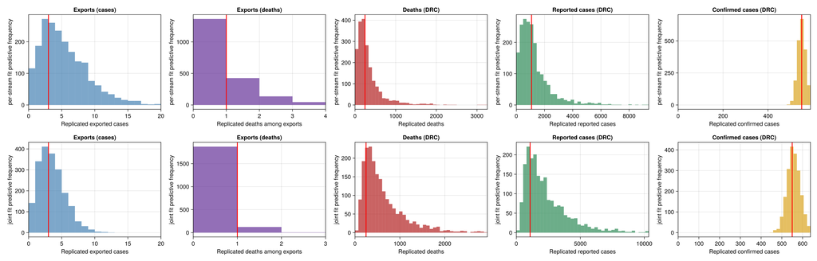

```julia
pp_exports_only = vec(Array(predict(
    exports_only_model(missing), chn_exports)[:exported_cases]));
pp_deaths_only = vec(Array(predict(
    deaths_only_model(missing), chn_deaths)[:total_deaths]));
pp_cases_only = vec(Array(predict(
    cases_only_model(missing), chn_cases)[:reported_cases]));
pp_exports_deaths_only = vec(sum.(predict(
    exports_deaths_only_model(fill(missing, length(obs.export_deaths_daily));
        pre_start_deaths = missing),
    chn_exports_deaths)[@varname(export_deaths_daily)]));
# Laboratory-pipeline fit: predict the confirmed Binomial from the
# confirmed-only posterior for the individual row of the grid (a
# single-vintage vector here). The analysed denominator is a conditioned
# input, so only the confirmed positives are generated.
pp_confirmed_only_chn = predict(
    confirmed_only_model(missing, obs.cumulative_tests_analysed),
    chn_confirmed);
pp_confirmed_only = vec(sum.(
    pp_confirmed_only_chn[@varname(confirmed_cases)]));

ppc_grid_fig = plot_posterior_predictive_grid(;
    individual = (; exports = pp_exports_only,
        exports_deaths = pp_exports_deaths_only,
        deaths = pp_deaths_only,
        cases = pp_cases_only,
        confirmed = pp_confirmed_only),
    joint = (; exports = pp_exports,
        exports_deaths = pp_exports_deaths,
        deaths = pp_deaths,
        cases = pp_cases,
        confirmed = pp_confirmed),
    observed = (; exports = obs.exported_cases,
        exports_deaths = obs.exports_deaths,
        deaths = obs.total_deaths,
        cases = obs.reported_cases,
        confirmed = obs.confirmed_cases)
);
```

**Overlaid C_T density plot**

julia

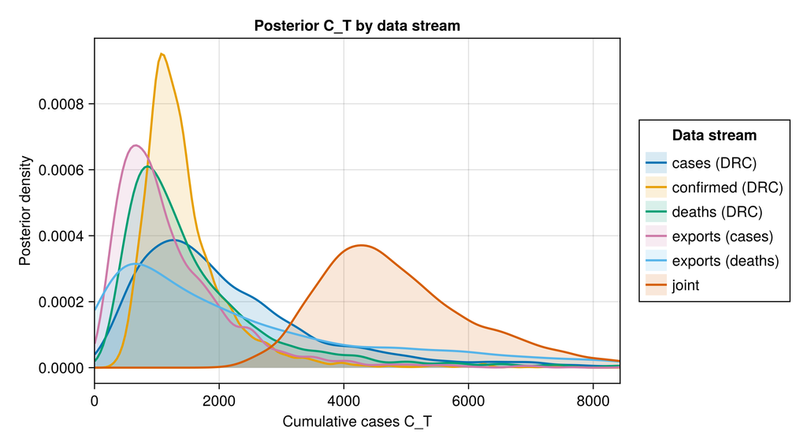

```julia
# Clip the x-axis to keep the bulk of every density legible: the
# exports-deaths fit has a very heavy upper tail (95% reaching several
# thousand), which otherwise stretches the axis and compresses the
# other curves. The cap is the widest 95% upper across the remaining
# fits, so only the exports-deaths tail is truncated.
density_xmax = 1.1 * maximum(quantile(v, 0.95)
for v in (
    posterior_C_exports, posterior_C_deaths, posterior_C_cases,
    posterior_C_confirmed, posterior_C_joint))
cumulative_density_fig = plot_cumulative_cases(
    "exports (cases)" => posterior_C_exports,
    "exports (deaths)" => posterior_C_exports_deaths,
    "deaths (DRC)" => posterior_C_deaths,
    "cases (DRC)" => posterior_C_cases,
    "confirmed (DRC)" => posterior_C_confirmed,
    "joint" => posterior_C_joint;
    scenarios = [], xmax = density_xmax);
```

### Comparison with McCabe et al.

Our joint fit against the McCabe et al. estimates and our Method 2 reproduction: point estimates with 95% intervals. We step through both report versions in turn — the 18 May version (McCabe and others, May 2026) and the 20 May version (McCabe and others, May 2026) — and end with our joint fit to the current data.

**Fit our model to each report version's data, and run the Method 2 reproductions**

julia

```julia
# The 18 May original report's data and its joint fit, for the C(T)
# comparison against the published Method 2 headline and our current-data
# fit.
obs_report = load_observations(
    joinpath(pkgdir(BVDOutbreakSize), "data", "report-snapshot.toml"));

report_args = joint_obs(obs_report)
chn_joint_report = nuts_sample(
    bvd_joint(obs_report.exported_cases, report_args.deaths,
    report_args.reported, report_args.export_deaths; report_args.kw...,
    growth = growth_for(obs_report),
    first_export_detection_delta =
    obs_report.first_export_detection_delta));
posterior_C_joint_report = vec(Array(chn_joint_report[:cumulative_cases]));

obs_report_20may = load_observations(
    joinpath(pkgdir(BVDOutbreakSize), "data",
    "report-snapshot-20may.toml"));

report_20may_args = joint_obs(obs_report_20may)
chn_joint_report_20may = nuts_sample(
    bvd_joint(obs_report_20may.exported_cases,
    report_20may_args.deaths, report_20may_args.reported,
    report_20may_args.export_deaths; report_20may_args.kw...,
    growth = growth_for(obs_report_20may),
    first_export_detection_delta =
    obs_report_20may.first_export_detection_delta));
posterior_C_joint_report_20may = vec(Array(chn_joint_report_20may[:cumulative_cases]));

imperial_fixed = Turing.fix(
    imperial_only_model(missing, 88),       # exports missing → pure Method 2
    # Pin the τ = 14 d scenario through the growth rate r = log(2)/14.
    (r = log(2) / 14, CFR = 0.30, α = 4.42, θ = 1/0.388,
        inv_sqrt_k = 1e-3)
)
chn_imperial = nuts_sample(imperial_fixed);
posterior_C_imperial = vec(Array(chn_imperial[:cumulative_cases]));

imperial_fixed_20may = Turing.fix(
    imperial_only_model(missing, 131),      # exports missing → pure Method 2
    # Pin the τ = 14 d scenario through the growth rate r = log(2)/14.
    (r = log(2) / 14, CFR = 0.33, α = 4.42, θ = 1/0.388,
        inv_sqrt_k = 1e-3)
)
chn_imperial_20may = nuts_sample(imperial_fixed_20may);
posterior_C_imperial_20may = vec(Array(chn_imperial_20may[:cumulative_cases]));
```

[output not shown]

The plot places each estimate of on one axis: the central estimate as a point, the 95% interval as a bar. Rows are grouped by report version. For each version the first two rows are McCabe et al.'s published Method 1 and Method 2 headline scenarios with their reported 95% confidence intervals, followed by our Method 2 reproduction and our joint fit to that version's data, both as 95% credible intervals. The final row is our joint fit to the current data.

**Build the comparison**

julia

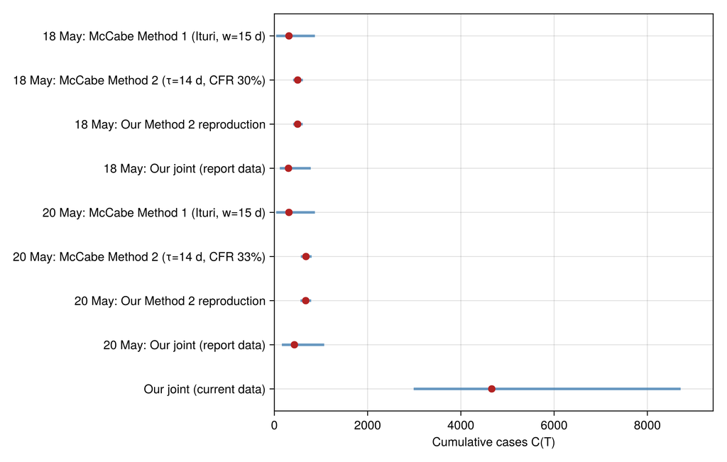

```julia
# Our model rows use 95% equal-tailed credible intervals, matching the
# 95% confidence intervals McCabe et al. report for both methods.
function ci95(xs)
    (round(Int, quantile(xs, 0.5)),
        round(Int, quantile(xs, 0.025)),
        round(Int, quantile(xs, 0.975)))
end

joint_ci = ci95(posterior_C_joint)
joint_report_ci = ci95(posterior_C_joint_report)
joint_report_20may_ci = ci95(posterior_C_joint_report_20may)
imperial_ci = ci95(posterior_C_imperial)
imperial_20may_ci = ci95(posterior_C_imperial_20may)

comparison_rows = [
    ("18 May: McCabe Method 1 (Ituri, w=15 d)", 313, 39, 870),
    ("18 May: McCabe Method 2 (τ=14 d, CFR 30%)", 501, 402, 612),
    ("18 May: Our Method 2 reproduction", imperial_ci...),
    ("18 May: Our joint (report data)", joint_report_ci...),
    ("20 May: McCabe Method 1 (Ituri, w=15 d)", 313, 39, 870),
    ("20 May: McCabe Method 2 (τ=14 d, CFR 33%)", 678, 568, 800),
    ("20 May: Our Method 2 reproduction", imperial_20may_ci...),
    ("20 May: Our joint (report data)", joint_report_20may_ci...),
    ("Our joint (current data)", joint_ci...)
]

comparison_fig = plot_estimate_comparison(comparison_rows);
```

Fit diagnostics for the two report-data joint fits and the two Method 2 reproductions.

**Fit diagnostics**

4×4 DataFrame

| Row | fit String | max_rhat Float64 | min_ess_bulk Float64 | divergences Int64 |
| --- | --- | --- | --- | --- |
| 1 | joint (18 May report) | 1.004 | 1340.0 | 4 |
| 2 | joint (20 May report) | 1.005 | 844.0 | 1 |
| 3 | Method 2 reproduction (18 May) | 1.001 | 1260.0 | 0 |
| 4 | Method 2 reproduction (20 May) | 1.002 | 941.0 | 0 |

The same comparison as a table, with a column for the report version:

**Comparison table**

julia

```julia
comparison_version = [
    "18 May", "18 May", "18 May", "18 May",
    "20 May", "20 May", "20 May", "20 May",
    "current"
]

main_comparison = DataFrame(
    "Report version" => comparison_version,
    "Source" => [r[1] for r in comparison_rows],
    "Central estimate" => [r[2] for r in comparison_rows],
    "Lower 95%" => [r[3] for r in comparison_rows],
    "Upper 95%" => [r[4] for r in comparison_rows]
);
```

9×5 DataFrame

| Row | Report version String | Source String | Central estimate Int64 | Lower 95% Int64 | Upper 95% Int64 |
| --- | --- | --- | --- | --- | --- |
| 1 | 18 May | 18 May: McCabe Method 1 (Ituri, w=15 d) | 313 | 39 | 870 |
| 2 | 18 May | 18 May: McCabe Method 2 (τ=14 d, CFR 30%) | 501 | 402 | 612 |
| 3 | 18 May | 18 May: Our Method 2 reproduction | 499 | 403 | 609 |
| 4 | 18 May | 18 May: Our joint (report data) | 303 | 117 | 781 |
| 5 | 20 May | 20 May: McCabe Method 1 (Ituri, w=15 d) | 313 | 39 | 870 |
| 6 | 20 May | 20 May: McCabe Method 2 (τ=14 d, CFR 33%) | 678 | 568 | 800 |
| 7 | 20 May | 20 May: Our Method 2 reproduction | 673 | 560 | 790 |
| 8 | 20 May | 20 May: Our joint (report data) | 430 | 161 | 1069 |
| 9 | current | Our joint (current data) | 4663 | 2988 | 8714 |

**Reproductions vs McCabe et al. Method 2**

julia

```julia
imperial_sense_check = let
    rep, lo, hi = imperial_ci
    rep2, lo2, hi2 = imperial_20may_ci
    delta = round(100 * (rep - 501) / 501; digits = 1)
    delta2 = round(100 * (rep2 - 678) / 678; digits = 1)
    Markdown.parse("""
    18 May reproduction: **$(rep) cases** (95% CrI $(lo)–$(hi)) against
    McCabe et al.'s reported **501** — a difference of $(delta)%.

    20 May reproduction: **$(rep2) cases** (95% CrI $(lo2)–$(hi2))
    against McCabe et al.'s reported **678** — a difference of
    $(delta2)%.
    """)
end;
```

18 May reproduction: **499 cases** (95% CrI 403–609) against McCabe et al.'s reported **501** — a difference of -0.4%.

20 May reproduction: **673 cases** (95% CrI 560–790) against McCabe et al.'s reported **678** — a difference of -0.7%.

Joint posterior coverage of all 15 published McCabe et al. scenarios — for each scenario, the narrowest joint credible interval that contains it:

**Joint coverage table**

julia

```julia
coverage_table = comparison_table(posterior_C_joint);
```

15×3 DataFrame

| Row | Scenario String | Reported cases Int64 | Narrowest interval String |
| --- | --- | --- | --- |
| 1 | Method 1 Ituri, w=10 d | 470 | outside 90% |
| 2 | Method 1 Ituri, w=15 d | 313 | outside 90% |
| 3 | Method 1 Ituri, w=20 d | 235 | outside 90% |
| 4 | Method 1 +N. Kivu, w=10 | 617 | outside 90% |
| 5 | Method 1 +N. Kivu, w=15 | 412 | outside 90% |
| 6 | Method 1 +N. Kivu, w=20 | 309 | outside 90% |
| 7 | Method 2 τ=14 d, CFR 26% | 860 | outside 90% |
| 8 | Method 2 τ=14 d, CFR 33% | 678 | outside 90% |
| 9 | Method 2 τ=14 d, CFR 40% | 559 | outside 90% |
| 10 | Method 2 τ= 7 d, CFR 26% | 1386 | outside 90% |
| 11 | Method 2 τ= 7 d, CFR 33% | 1092 | outside 90% |
| 12 | Method 2 τ= 7 d, CFR 40% | 901 | outside 90% |
| 13 | Method 2 τ=21 d, CFR 26% | 730 | outside 90% |
| 14 | Method 2 τ=21 d, CFR 33% | 575 | outside 90% |
| 15 | Method 2 τ=21 d, CFR 40% | 474 | outside 90% |

The joint density with the 15 published scenario point estimates overlaid as faint dashed rules, for our current-data fit and our fits to each report version's data:

**Joint C_T density with published scenarios**

julia

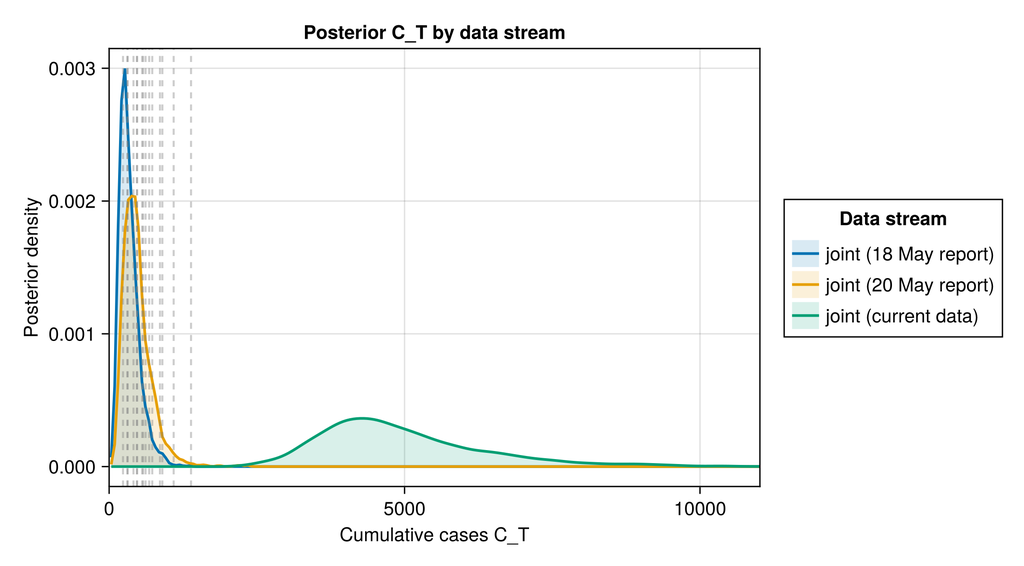

```julia
imperial_density_fig = plot_cumulative_cases(
    "joint (current data)" => posterior_C_joint,
    "joint (18 May report)" => posterior_C_joint_report,
    "joint (20 May report)" => posterior_C_joint_report_20may);
```

## Saving results

**Write outputs to output/**

julia

```julia
# Outputs default to `output/` in the package directory (where the
# docs build and Release workflow expect them). Set `BVD_OUTPUT_DIR`
# to redirect them, e.g. when running from a read-only package
# install.
output_dir = get(ENV, "BVD_OUTPUT_DIR",
    joinpath(pkgdir(BVDOutbreakSize), "output"))
mkpath(output_dir)

CSV.write(joinpath(output_dir, "posterior_summary.csv"), joint_summary)
CSV.write(joinpath(output_dir, "cumulative_cases_by_stream.csv"),
    streams_C_table)
CSV.write(joinpath(output_dir, "imperial_comparison.csv"), main_comparison)
CSV.write(joinpath(output_dir, "scenario_coverage.csv"), coverage_table)
CSV.write(joinpath(output_dir, "forecast_validation.csv"),
    forecast_validation_table)

# Copy the input data so the release records what produced these
# results.
cp(joinpath(pkgdir(BVDOutbreakSize), "data", "observations.toml"),
    joinpath(output_dir, "observations.toml"); force = true)

# Thinned posterior draws of the key joint parameters (every 10th
# draw) so downstream users can recompute their own summaries.
posterior_draws = DataFrame(
    τ = vec(Array(chn_joint[:τ])),
    r = vec(Array(chn_joint[:r])),
    m = vec(Array(chn_joint[:m])),
    T = vec(Array(chn_joint[:T])),
    CFR = vec(Array(chn_joint[:CFR])),
    p_drc = vec(Array(chn_joint[:p_drc])),
    p_uganda = vec(Array(chn_joint[:p_uganda])),
    cumulative_cases = vec(Array(chn_joint[:cumulative_cases]))
)[1:10:end, :]
CSV.write(joinpath(output_dir, "posterior_draws.csv"), posterior_draws);
```

The full analysis code, data and model definitions are in the epiforecasts/BVDOutbreakSize repository. Issues, corrections and suggestions are welcome there. Maintained by Sam Abbott, Kath Sherratt, Samuel Brand and Sebastian Funk.